# Machine Learning Project - Coursera Data Science

pepper416

August 23, 2014

### Executive Summary

This is my final project for the [Johns Hopkins’ Coursera course -Data Science specialization “Practical Machine Learning”](https://www.coursera.org/course/predmachlearn). The objective of this project is to predict one of five different fashions of performing the Unilateral Dumbbell Biceps Curl (i.e. the `classe` variable in the training dataset), based on observations from accelerometers on the belt, forearm, arm, and dumbell. The five different fashions are:

- A = Exactly according to the specification
- B = Throwing the elbows to the front
- C = Lifting the dumbbell only halfway
- D = Lowering the dumbbell only halfway
- E = Throwing the hips to the front

The data are split into a training group (19,622) observations and testing group (20 observations). More information about this dataset is available from the website here: http://groupware.les.inf.puc-rio.br/har

It is important to split the training dataset into a training dataset and a cross validation datasets. This is useful to estimate the errors from the model.

In this report, we tried the rpart model and random forest model. Random forest gives us 99% prediction accuracy. We are more confident to use the random forest model to predict the 20 test examples.

The report contains the following sections:

1. Data Preparation
2. Model Selection
3. Test Data Prediction

### Data Preparation

You need the following packages to run this analysis

```r
library(caret)
library(rattle)
set.seed(516)
```

Download the training data from https://d396qusza40orc.cloudfront.net/predmachlearn/pml-training.csv and the test data are available from https://d396qusza40orc.cloudfront.net/predmachlearn/pml-testing.csv

```r
training <- read.csv("pml-training.csv", header = TRUE, na.strings = c("NA", ""))[,-1]
testing <- read.csv("pml-testing.csv", header = TRUE, na.strings = c("NA", ""))[,-1]
sum(colSums(is.na(training))==0) #count how many columns don't have NAs in the training dataset
```

```
## [1] 59
```

```r
sum(colSums(is.na(testing))==0) #count how many columns don't have NAs in the testing dataset
```

```
## [1] 59
```

```r
training1 <- training[,colSums(is.na(training))==0]
testing1<- testing[,colSums(is.na(testing))==0]
```

The following 6 features seem not to be useful in predicting classe, so we will remove those 6 features as well: “user_name” “raw_timestamp_part_1” “raw_timestamp_part_2” “cvtd_timestamp” “new_window” “num_window”

```r
o = which(names(training1) %in% c("user_name", "raw_timestamp_part_1", "raw_timestamp_part_2", "cvtd_timestamp", "new_window", "num_window"))
training_clean <- training1[,-o]
testing_clean<- testing1[,-o]
```

Finally, in the cleaned dataset, there are only 53 columns left.

We will split the cleaned training dataset into training (80%) and validation (20%) datasets. This validation dataset will allow us to perform cross validation for developing and testing our model.

```r
inTrain = createDataPartition(training_clean$classe, p = 0.8)[[1]]

train = training_clean[ inTrain,]
validate = training_clean[-inTrain,]
dim(train)
```

```
## [1] 15699    53
```

### Model Selection

In this section we will try different models that we learned from this course and select the best one.

#### Model1: rpart

The first option is the simple decision tree, by using rpart method.

```r
modFit1 <- train(as.factor(classe) ~ ., method='rpart', data=train)
```

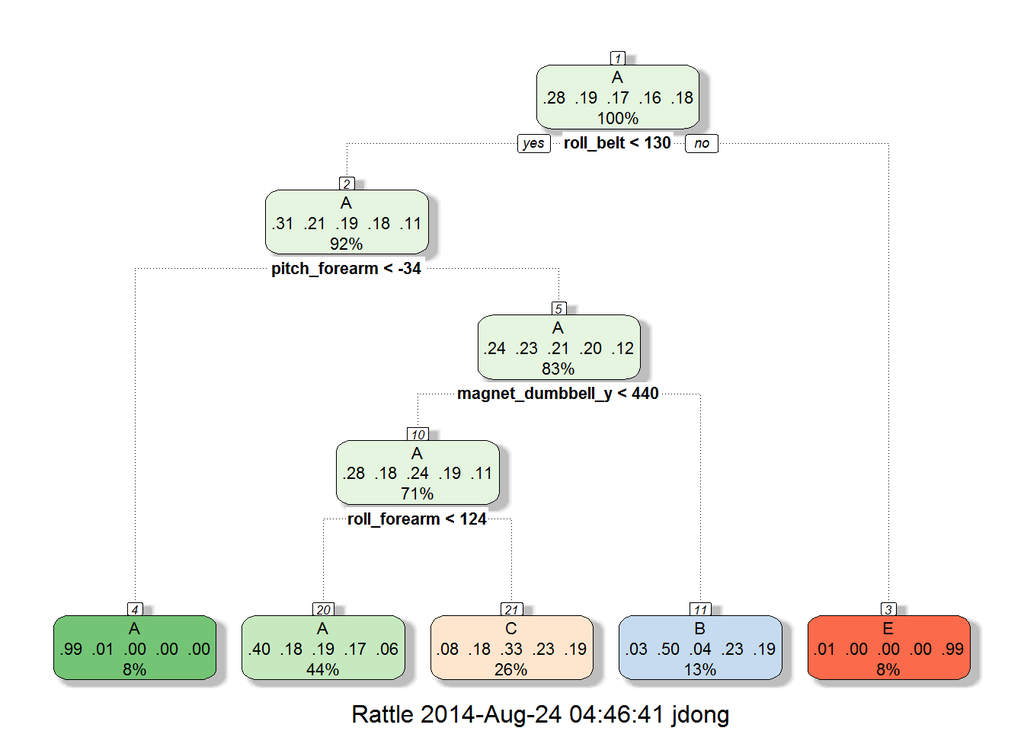

```r
fancyRpartPlot(modFit1$finalModel)
```

```r
pred_mod1 = predict(modFit1, newdata = validate)
confusionMatrix(validate$classe, pred_mod1)
```

```
## Confusion Matrix and Statistics
##
##           Reference
## Prediction    A    B    C    D    E
##          A 1019   14   80    0    3
##          B  316  273  170    0    0
##          C  303   20  361    0    0
##          D  282  116  245    0    0
##          E  103   99  196    0  323
##
## Overall Statistics
##
##                Accuracy : 0.5037
##                  95% CI : (0.4879, 0.5195)
##     No Information Rate : 0.5157
##     P-Value [Acc > NIR] : 0.9354
##
##                   Kappa : 0.3517
##  Mcnemar's Test P-Value : NA
##
## Statistics by Class:
##
##                      Class: A Class: B Class: C Class: D Class: E
## Sensitivity            0.5037  0.52299  0.34316       NA  0.99080
## Specificity            0.9489  0.85710  0.88750   0.8361  0.88935
## Pos Pred Value         0.9131  0.35968  0.52778       NA  0.44799
## Neg Pred Value         0.6423  0.92130  0.78666       NA  0.99906
## Prevalence             0.5157  0.13306  0.26816   0.0000  0.08310
## Detection Rate         0.2598  0.06959  0.09202   0.0000  0.08233
## Detection Prevalence   0.2845  0.19347  0.17436   0.1639  0.18379
## Balanced Accuracy      0.7263  0.69004  0.61533       NA  0.94007
```

This model can only correctly predict 50.4% of the validation data.

#### Model2: Random Forest

We will try the random forest model below

```r
modFit2 <- train(as.factor(classe) ~ ., method='rf', data=train, trControl = trainControl(method = "cv"))
pred_mod2 = predict(modFit2, newdata = validate)
confusionMatrix(validate$classe, pred_mod2)
```

```
## Confusion Matrix and Statistics
##
##           Reference
## Prediction    A    B    C    D    E
##          A 1116    0    0    0    0
##          B    1  754    4    0    0
##          C    0    4  678    2    0
##          D    0    0    4  639    0
##          E    0    0    0    2  719
##
## Overall Statistics
##
##                Accuracy : 0.9957
##                  95% CI : (0.9931, 0.9975)
##     No Information Rate : 0.2847
##     P-Value [Acc > NIR] : < 2.2e-16
##
##                   Kappa : 0.9945
##  Mcnemar's Test P-Value : NA
##
## Statistics by Class:
##
##                      Class: A Class: B Class: C Class: D Class: E
## Sensitivity            0.9991   0.9947   0.9883   0.9938   1.0000
## Specificity            1.0000   0.9984   0.9981   0.9988   0.9994
## Pos Pred Value         1.0000   0.9934   0.9912   0.9938   0.9972
## Neg Pred Value         0.9996   0.9987   0.9975   0.9988   1.0000
## Prevalence             0.2847   0.1932   0.1749   0.1639   0.1833
## Detection Rate         0.2845   0.1922   0.1728   0.1629   0.1833
## Detection Prevalence   0.2845   0.1935   0.1744   0.1639   0.1838
## Balanced Accuracy      0.9996   0.9966   0.9932   0.9963   0.9997
```

The accuracy from the random forest model is 99.6%!

### Test Data Prediction

Finally, we can use the random forest model to predict the 20 testing examples.

```r
answers = predict(modFit2, newdata = testing_clean)
answers
```

```
##  [1] B A B A A E D B A A B C B A E E A B B B
## Levels: A B C D E
```

Write the predicted results as .txt file and upload to the course project submission page.

```r
pml_write_files = function(x){
  n = length(x)
  for(i in 1:n){
    filename = paste0("problem_id_",i,".txt")
    write.table(x[i],file=filename,quote=FALSE,row.names=FALSE,col.names=FALSE)
  }
}

pml_write_files(answers)
```